# Does feeding rate predict entomology at the cluster level?

N. Moghaddas

2023-06-08

The main purpose of this document is to explore whether cluster level feeding rates can be used to predict entomological outcomes in the same cluster. This adds justification to the proposal to measure feeding rates in ATSB clusters in the ongoing ATSB trials. The only study in which feeding rates were measured in the same clusters as ATSB was deployed was the original proof of concept trial in Mali undertaken in 2016-2017. This was a purely entomological trial so no epidemiological measurements were taken. Therefore I will also look at the variability in count data to determine how reliable it can be as an indicator of efficacy. This document also explores potential drivers of variability in feeding rate by looking for correlation with natural sugar feeding. This file makes use of two sources of data on the Mali trials: count data reported from CDC traps placed in all fourteen villages throughout the baseline year and the trial year, and data on the fraction of mosquitoes caught that were dyed due to having fed on a non toxic bait station.

## Step 1

The method which was used for measuring feeding rates in this trial is different to the trials currently underway. In Mali, ASB stations were essentially deployed during a single day and mosquitoes were caught over night from 6.00pm to 6.00am. A sample was taken from that catch to determine the dyed fraction. As a previous study had shown that mosquito sugar feeding occurs predominantly at night and early dawn, this dyed fraction was assumed to be equivalent to the daily feeding rate. Here is the feeding rate data from the Mali trial.

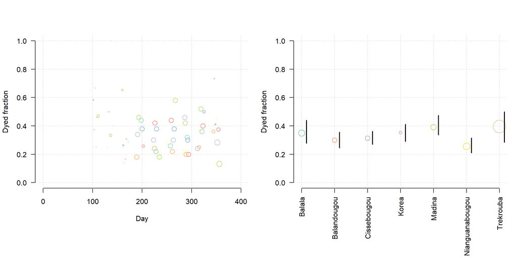

## Step 2

Each village also has mosquito abundance data over two years. In 2017, ATSB was deployed in half of the villages.

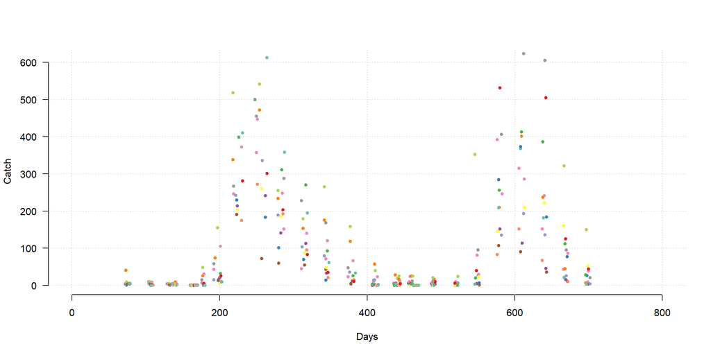

Let’s look at the trajectories for each cluster

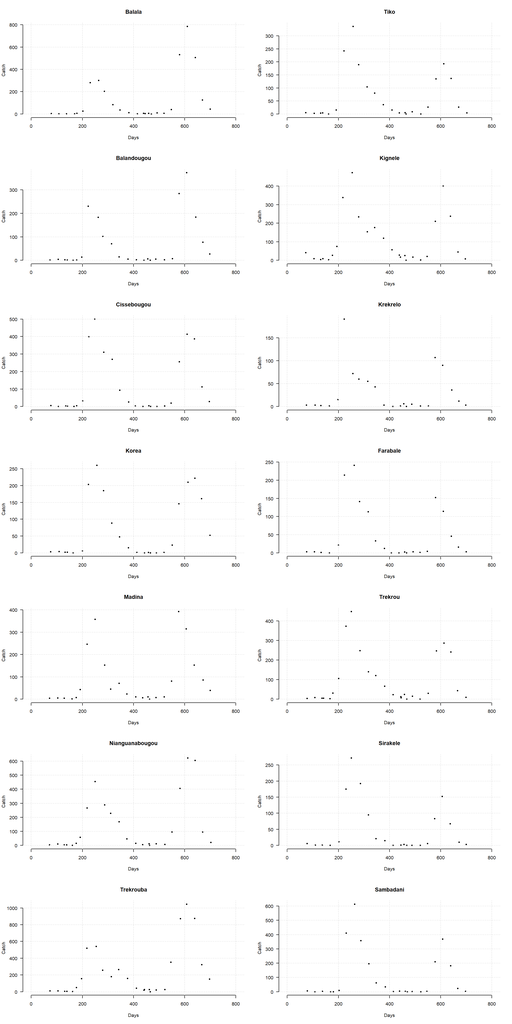

## Step 3: Compare feeding rate to the reduction in catch relative to control

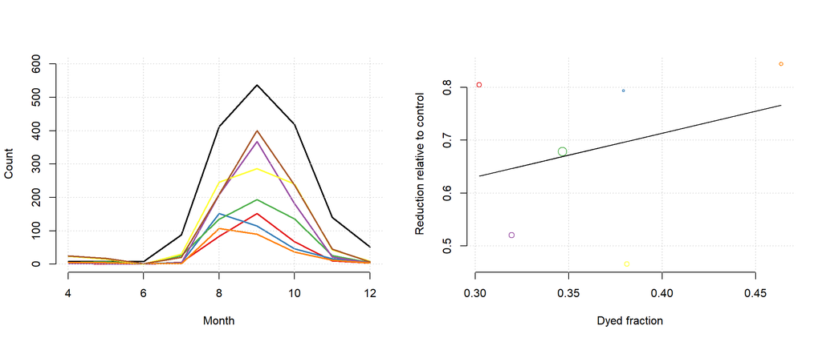

```
##
## Call:
## lm(formula = reduction[1:6] ~ asb_feeding$dyed_fraction[1:6])
##
## Residuals:
##         1         2         3         4         5         6
##  0.172657  0.097849  0.009419 -0.125795  0.077775 -0.231906
##
## Coefficients:
##                                Estimate Std. Error t value Pr(>|t|)
## (Intercept)                      0.3810     0.4866   0.783    0.477
## asb_feeding$dyed_fraction[1:6]   0.8307     1.3183   0.630    0.563
##
## Residual standard error: 0.1697 on 4 degrees of freedom
## Multiple R-squared:  0.0903, Adjusted R-squared:  -0.1371
## F-statistic: 0.397 on 1 and 4 DF,  p-value: 0.5628
```

## Step 4: Compare the feeding rate to the reduction in catch relative to 2016

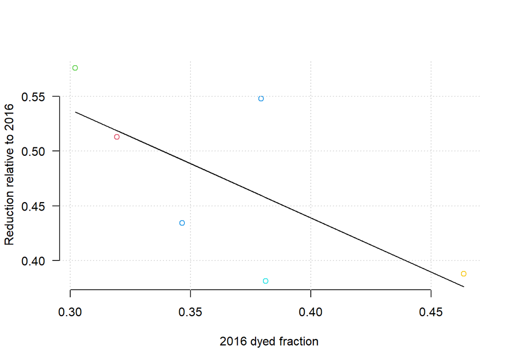

```
##
## Call:
## lm(formula = catch$reduction[1:6] ~ catch$dyed_fraction[1:6])
##
## Residuals:
##         1         2         3         4         5         6
##  0.039914  0.088498 -0.057899 -0.005713  0.011710 -0.076509
##
## Coefficients:
##                          Estimate Std. Error t value Pr(>|t|)
## (Intercept)                0.8352     0.1966   4.247   0.0132 *
## catch$dyed_fraction[1:6]  -0.9903     0.5328  -1.859   0.1366
## ---
## Signif. codes:  0 '***' 0.001 '**' 0.01 '*' 0.05 '.' 0.1 ' ' 1
##
## Residual standard error: 0.06856 on 4 degrees of freedom
## Multiple R-squared:  0.4635, Adjusted R-squared:  0.3293
## F-statistic: 3.455 on 1 and 4 DF,  p-value: 0.1366
```